# R Notebook

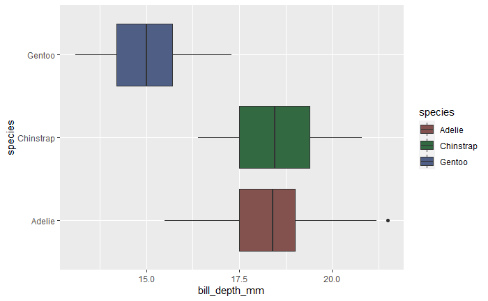

```r
#Initial plot to see which parameters might yield clues about species types
#Species vs bill depth
bp<-ggplot(aes(x = species, y = bill_depth_mm, fill=species), data = df) + geom_boxplot() + coord_flip()

bp + scale_fill_hue(l=40, c=35)
```

### Chinstrap and Adelie penguins have overlap in bill depth.

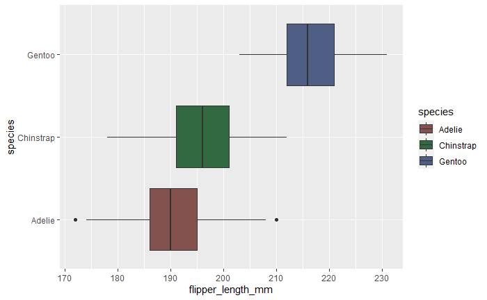

```r
#Initial plot to see which parameters might yield clues about species types
#Species vs flipper length
bp<-ggplot(aes(x = species, y = flipper_length_mm, fill=species), data = df) + geom_boxplot() + coord_flip()

bp + scale_fill_hue(l=40, c=35)
```

### And lastly, Chinstrap and Adelie penguins have some overlap in flipper length

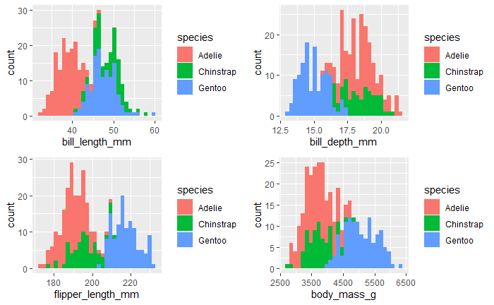

```r
#Grid analysis of histograms of the parameters: Length and Width and the Petal Length and Width.
# "species"           "island"            "bill_length_mm"    "bill_depth_mm"     "flipper_length_mm"
# "body_mass_g"       "sex"               "year"

p1 <- ggplot(aes(x = bill_length_mm, fill = species), data = df) +
  geom_histogram()

p2 <- ggplot(aes(x = bill_depth_mm, fill = species), data = df) +
   geom_histogram()

p3 <- ggplot(aes(x = flipper_length_mm, fill = species), data = df) + geom_histogram()

p4 <- ggplot(aes(x = body_mass_g, fill = species), data = df) +
   geom_histogram()


grid.arrange(p1, p2, p3, p4, ncol = 2)
```

### Again, using the histograms, we the same overlaps in a more colorful fashion.

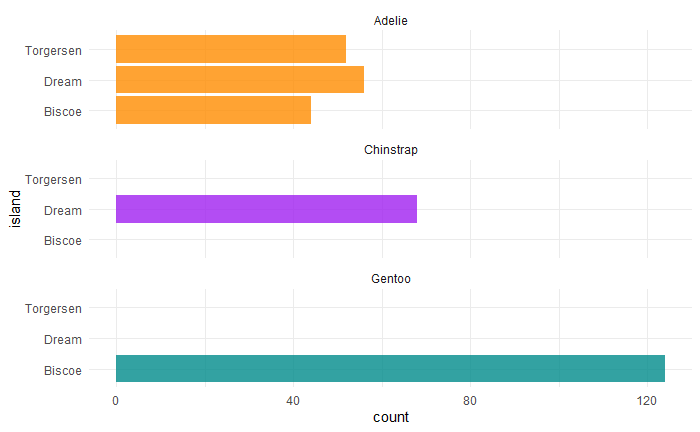

```r
#Looking at which penguins were measure on which islands

ggplot(penguins, aes(x = island, fill = species)) +
  geom_bar(alpha = 0.8) +
  scale_fill_manual(values = c("darkorange","purple","cyan4"),
                    guide = FALSE) +
  theme_minimal() +
  facet_wrap(~species, ncol = 1) +
  coord_flip()
```

```r
NA
NA
```

### It would appear for the study that Adelie penguins can be found on all

### three islands, which Chinstraps were exclusive to only Dream and

### Gentoo exclusive only to Biscoe.

[output not shown]

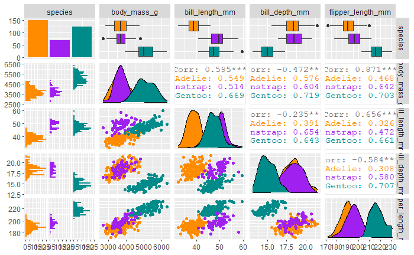

```r
penguins %>%
  select(species, body_mass_g, ends_with("_mm")) %>%
  GGally::ggpairs(aes(color = species)) +
  scale_colour_manual(values = c("darkorange","purple","cyan4")) +
  scale_fill_manual(values = c("darkorange","purple","cyan4"))
```

### The pairwise graph sums up our previous findings.

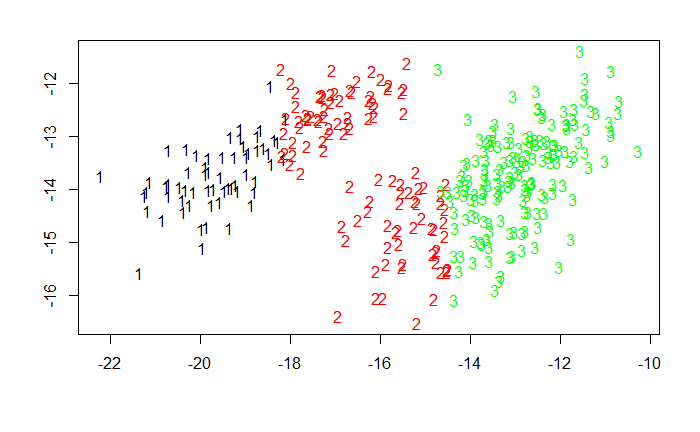

```r
#Before modeling, it is good to look to see if there is any clustering in
#the data set

#Variables used in clustering "Island", bill_length_mm", "bill_depth_mm",
#"flipper_length_mm", and "body_mass_g"

#Seed for starting number used to generate a sequence of random numbers
set.seed(20)

#Creating new dataframe for clustering.
data_for_clustering <- df

#Dropping "NA" values
data_for_clustering_no_na <- drop_na(data_for_clustering)

#kmeans data clustering partitioning (assuming 3 centers or clusters).

#Using Species as the target, with features "bill_length_mm" "bill_depth_mm"     #"flipper_length_mm" and "body_mass_g"

clusters_penguins <- kmeans(data_for_clustering_no_na[,4:6], centers = 3)

plotcluster(data_for_clustering_no_na[,3:6], clusters_penguins$cluster, color = TRUE, shade = TRUE, xlab="", ylab="")
```

#Clustering does indicate that there is some separation in the penguin data #that might lend itself for modeling.

```r
#Creating clustering table to exam if there is proper separation
penguins_no_na <- drop_na(penguins)

table(clusters_penguins$cluster, penguins_no_na$species)
```

```
    Adelie Chinstrap Gentoo
  1      0         0     61
  2     34        15     57
  3    112        53      1
```

#It appears that some of the penguins aren’t properly categorized due to the #feature overlaps

#Modeling Work #Goal is to determine if a model can be built to predict the species of penguin #based on measurements

#Data will be split into a test set and a validation set.

```r
#Create a Validation Dataset

#Starting with clean dataframe and removing "NA" values


data_for_model <- df

#Dropping "NA" values
data_for_model_no_na <- drop_na(data_for_model)


set.seed(300)

validation_index <- createDataPartition(data_for_model_no_na$species, p=0.80, list=FALSE)

# select 20% of the data for validation
validation <- data_for_model_no_na[-validation_index,]


# use the remaining 80% of data to training and testing the models
data_for_model_no_na <- data_for_model_no_na[validation_index,]
```

```
The `i` argument of ``[`()` can't be a matrix as of tibble 3.0.0.
Convert to a vector.
```

```r
#Summary of the data set
dim(data_for_model_no_na)
```

```
[1] 268   8
```

```r
dim(validation)
```

```
[1] 65  8
```

###Validation and Modeling dataframes have correct proportions

```r
# list types for each attribute
sapply(data_for_model_no_na, class)
```

```
          species            island    bill_length_mm     bill_depth_mm
         "factor"          "factor"         "numeric"         "numeric"
flipper_length_mm       body_mass_g               sex              year
        "integer"         "integer"          "factor"         "integer"
```

```r
# take a peek at the first 5 rows of the data
head(data_for_model_no_na)
```

| species | island | bill_length_mm | bill_depth_mm | flipper_length_mm | body_mass_g | sex | year |
| --- | --- | --- | --- | --- | --- | --- | --- |
| Adelie | Torgersen | 39.1 | 18.7 | 181 | 3750 | male | 2007 |
| Adelie | Torgersen | 39.5 | 17.4 | 186 | 3800 | female | 2007 |
| Adelie | Torgersen | 40.3 | 18.0 | 195 | 3250 | female | 2007 |
| Adelie | Torgersen | 36.7 | 19.3 | 193 | 3450 | female | 2007 |
| Adelie | Torgersen | 39.3 | 20.6 | 190 | 3650 | male | 2007 |
| Adelie | Torgersen | 39.2 | 19.6 | 195 | 4675 | male | 2007 |

```r
# list the levels for the class
levels(data_for_model_no_na$species)
```

```
[1] "Adelie"    "Chinstrap" "Gentoo"
```

#Looking at the above data reads, the modeling dataframe checks out.

```r
# summarize the class distribution
percentage <- prop.table(table(data_for_model_no_na$species)) * 100
cbind(freq=table(data_for_model_no_na$species), percentage=round(percentage,1))
```

```
          freq percentage
Adelie     117       43.7
Chinstrap   55       20.5
Gentoo      96       35.8
```

```r
# summarize attribute distributions
summary(data_for_model_no_na)
```

```
      species          island    bill_length_mm  bill_depth_mm   flipper_length_mm
 Adelie   :117   Biscoe   :135   Min.   :32.10   Min.   :13.10   Min.   :172.0
 Chinstrap: 55   Dream    : 97   1st Qu.:39.20   1st Qu.:15.57   1st Qu.:190.0
 Gentoo   : 96   Torgersen: 36   Median :44.05   Median :17.30   Median :197.0
                                 Mean   :43.88   Mean   :17.14   Mean   :200.8
                                 3rd Qu.:48.40   3rd Qu.:18.62   3rd Qu.:212.2
                                 Max.   :59.60   Max.   :21.20   Max.   :231.0
  body_mass_g       sex           year
 Min.   :2700   female:137   Min.   :2007
 1st Qu.:3550   male  :131   1st Qu.:2007
 Median :4000                Median :2008
 Mean   :4192                Mean   :2008
 3rd Qu.:4750                3rd Qu.:2009
 Max.   :6050                Max.   :2009
```

```r
#Visualize Data set


# split input and output
x <- data_for_model_no_na[,3:6]
y <- data_for_model_no_na[,1]
```

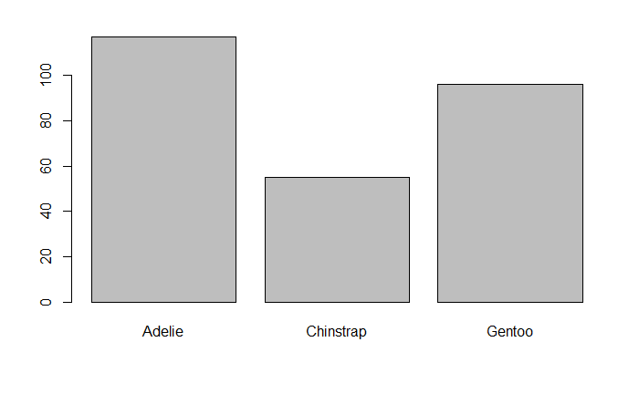

```r
# barplot for class breakdown
plot(y)
```

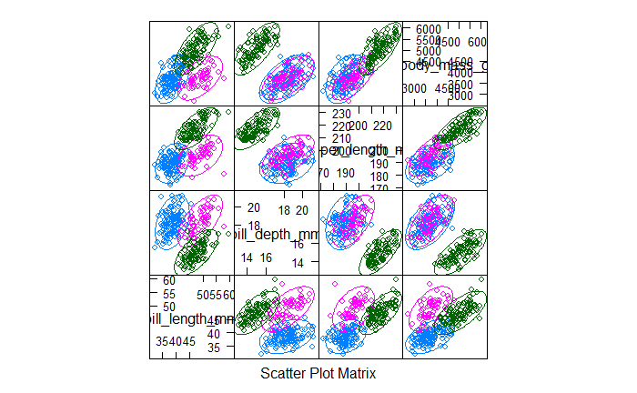

```r
# scatterplot matrix
featurePlot(x=x, y=y$species, plot="ellipse")
```

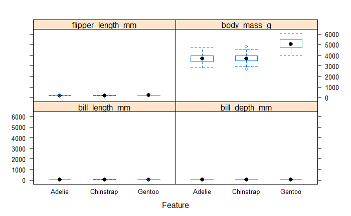

```r
# box and whisker plots for each attribute
featurePlot(x=x, y=y$species, plot="box")
```

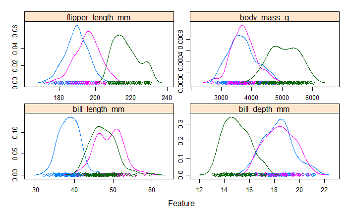

```r
# density plots for each attribute by class value
scales <- list(x=list(relation="free"), y=list(relation="free"))
featurePlot(x=x, y=y$species, plot="density", scales=scales)
```

```r
#Evaluate 5 different Algorithms

# Run algorithms using 10-fold cross validation
control <- trainControl(method="cv", number=10, savePredictions = TRUE)
metric <- "Accuracy"
```

```r
# a) linear algorithms
set.seed(7)
fit.lda <- train(species~., data=data_for_model_no_na, method="lda", metric=metric, trControl=control)


# b) nonlinear algorithms
# CART
set.seed(7)
fit.cart <- train(species~., data=data_for_model_no_na, method="rpart", metric=metric, trControl=control)

# kNN
set.seed(7)
fit.knn <- train(species~., data=data_for_model_no_na, method="knn", metric=metric, trControl=control)

# c) advanced algorithms
# SVM
set.seed(7)
fit.svm <- train(species~., data=data_for_model_no_na, method="svmRadial", metric=metric, trControl=control)

# Random Forest
set.seed(7)
fit.rf <- train(species~., data=data_for_model_no_na, method="rf", metric=metric, trControl=control)
```

```r
# summarize accuracy of models
results <- resamples(list(lda=fit.lda, cart=fit.cart, knn=fit.knn, svm=fit.svm, rf=fit.rf))
summary(results)
```

```
Call:
summary.resamples(object = results)

Models: lda, cart, knn, svm, rf
Number of resamples: 10

Accuracy
          Min.   1st Qu.   Median      Mean   3rd Qu.      Max. NA's
lda  0.9629630 1.0000000 1.000000 0.9962963 1.0000000 1.0000000    0
cart 0.8888889 0.9348291 0.962963 0.9589642 0.9910714 1.0000000    0
knn  0.6428571 0.7425214 0.792735 0.7769638 0.8148148 0.8846154    0
svm  0.9615385 1.0000000 1.000000 0.9961538 1.0000000 1.0000000    0
rf   0.9615385 1.0000000 1.000000 0.9924501 1.0000000 1.0000000    0

Kappa
          Min.   1st Qu.    Median      Mean   3rd Qu.      Max. NA's
lda  0.9430380 1.0000000 1.0000000 0.9943038 1.0000000 1.0000000    0
cart 0.8269231 0.8958654 0.9424867 0.9355850 0.9862745 1.0000000    0
knn  0.4117647 0.5935413 0.6606441 0.6409066 0.7018256 0.8164706    0
svm  0.9379475 1.0000000 1.0000000 0.9937947 1.0000000 1.0000000    0
rf   0.9379475 1.0000000 1.0000000 0.9880132 1.0000000 1.0000000    0
```

#At first blush, lda has the highest accuracy with SVM and rf following closely

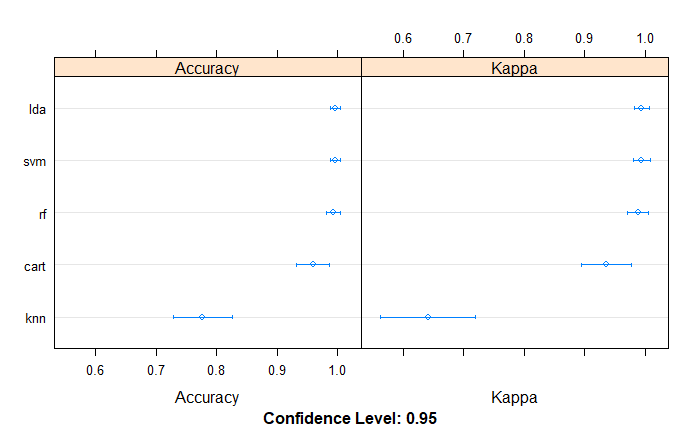

```r
# compare accuracy of models
dotplot(results)
```

```r
# Summarize Best Model
print(fit.lda)
```

```
Linear Discriminant Analysis

268 samples
  7 predictor
  3 classes: 'Adelie', 'Chinstrap', 'Gentoo'

No pre-processing
Resampling: Cross-Validated (10 fold)
Summary of sample sizes: 241, 240, 242, 241, 241, 242, ...
Resampling results:

  Accuracy   Kappa
  0.9962963  0.9943038
```

```r
# estimate skill of best model on the validation dataset
predictions <- predict(fit.lda, validation)
confusionMatrix(predictions, validation$species)
```

```
Confusion Matrix and Statistics

           Reference
Prediction  Adelie Chinstrap Gentoo
  Adelie        29         0      0
  Chinstrap      0        13      0
  Gentoo         0         0     23

Overall Statistics

               Accuracy : 1
                 95% CI : (0.9448, 1)
    No Information Rate : 0.4462
    P-Value [Acc > NIR] : < 2.2e-16

                  Kappa : 1

 Mcnemar's Test P-Value : NA

Statistics by Class:

                     Class: Adelie Class: Chinstrap Class: Gentoo
Sensitivity                 1.0000              1.0        1.0000
Specificity                 1.0000              1.0        1.0000
Pos Pred Value              1.0000              1.0        1.0000
Neg Pred Value              1.0000              1.0        1.0000
Prevalence                  0.4462              0.2        0.3538
Detection Rate              0.4462              0.2        0.3538
Detection Prevalence        0.4462              0.2        0.3538
Balanced Accuracy           1.0000              1.0        1.0000
```

###In Summary, the data set is rather small with only 344 measurements. ###However, there appears to be enough variance in the features to be able ###to use modeling to predict the penguin species based on the measurements. ###Possible next steps would be to gather more penguin data.